# 3.7 Exercises

# Exercise 9

This question involves the use of multiple linear regression on the **Auto** data set.

1. Produce a scatterplot matrix which includes all of the variables in the data set.

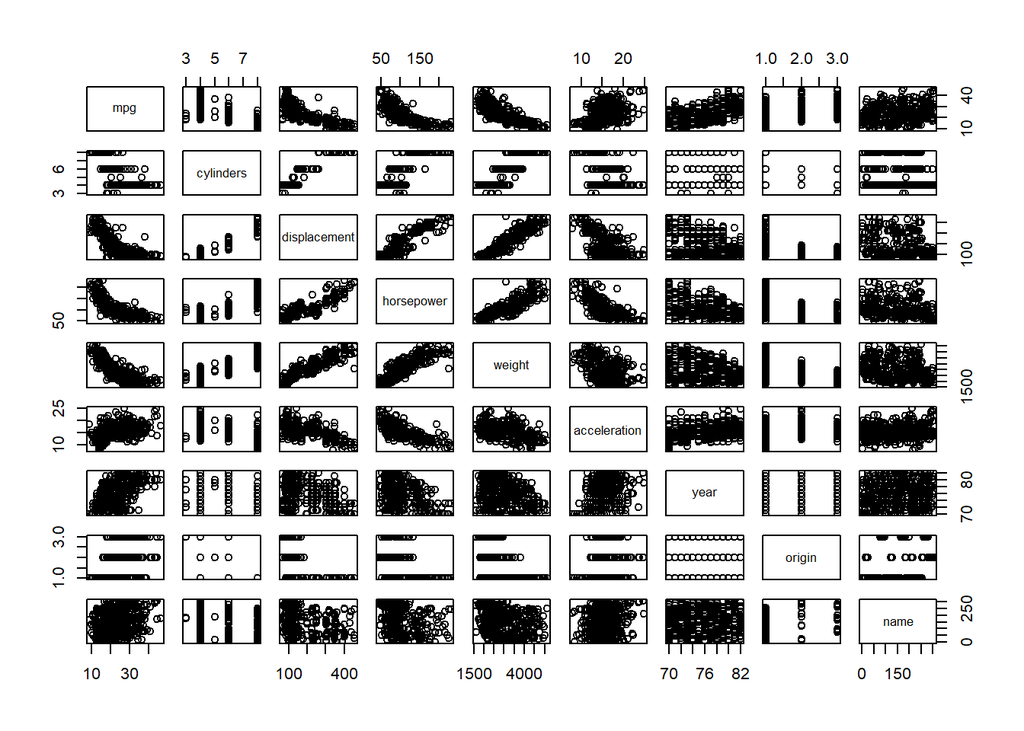

```r
pairs(Auto)
```

2. Compute the matrix of correlations between the variables using the function **cor()**. You will need to exclude the **name** variable, which is qualitative.

```r
cor(Auto[,-which(names(Auto) == 'name')])
```

```
##                     mpg  cylinders displacement horsepower     weight
## mpg           1.0000000 -0.7762599   -0.8044430         NA -0.8317389
## cylinders    -0.7762599  1.0000000    0.9509199         NA  0.8970169
## displacement -0.8044430  0.9509199    1.0000000         NA  0.9331044
## horsepower           NA         NA           NA          1         NA
## weight       -0.8317389  0.8970169    0.9331044         NA  1.0000000
## acceleration  0.4222974 -0.5040606   -0.5441618         NA -0.4195023
## year          0.5814695 -0.3467172   -0.3698041         NA -0.3079004
## origin        0.5636979 -0.5649716   -0.6106643         NA -0.5812652
##              acceleration       year     origin
## mpg             0.4222974  0.5814695  0.5636979
## cylinders      -0.5040606 -0.3467172 -0.5649716
## displacement   -0.5441618 -0.3698041 -0.6106643
## horsepower             NA         NA         NA
## weight         -0.4195023 -0.3079004 -0.5812652
## acceleration    1.0000000  0.2829009  0.2100836
## year            0.2829009  1.0000000  0.1843141
## origin          0.2100836  0.1843141  1.0000000
```

*The data pairs with high magnitudes of correlation also have scatter plots with patterns in the data.*

3. Use the **lm()** function to perform a multiple linear regression with **mpg** as the response and all other variables except **name** as the predictors. Use the **summary()** function to print the results.

```r
lm.fit = lm(mpg~.-name, data = Auto)
summary(lm.fit)
```

```
##
## Call:
## lm(formula = mpg ~ . - name, data = Auto)
##
## Residuals:
##     Min      1Q  Median      3Q     Max
## -9.5903 -2.1565 -0.1169  1.8690 13.0604
##
## Coefficients:
##                Estimate Std. Error t value Pr(>|t|)
## (Intercept)  -17.218435   4.644294  -3.707  0.00024 ***
## cylinders     -0.493376   0.323282  -1.526  0.12780
## displacement   0.019896   0.007515   2.647  0.00844 **
## horsepower    -0.016951   0.013787  -1.230  0.21963
## weight        -0.006474   0.000652  -9.929  < 2e-16 ***
## acceleration   0.080576   0.098845   0.815  0.41548
## year           0.750773   0.050973  14.729  < 2e-16 ***
## origin         1.426141   0.278136   5.127 4.67e-07 ***
## ---
## Signif. codes:  0 '***' 0.001 '**' 0.01 '*' 0.05 '.' 0.1 ' ' 1
##
## Residual standard error: 3.328 on 384 degrees of freedom
##   (5 observations deleted due to missingness)
## Multiple R-squared:  0.8215, Adjusted R-squared:  0.8182
## F-statistic: 252.4 on 7 and 384 DF,  p-value: < 2.2e-16
```

1. Is there a relationship between the predictors and the response?

*The F-statistic is quite large and the p-value is very small, so we may reject the null hypothesis and say that there is a relationship between the predictors and the mpg.*

2. Which predictors appear to have a statistically significant relationship to the response?

*Displacement, weight, year, and origin all have p-values less than 1% (as does the Intercept). These predictors therefore seem to be statistically significant.*

3. What does the coefficient for the **year** variable suggest?

*$\hat{\beta_year} = 0.750773$ and has a very low p-value. The data therefore suggests that fuel efficiency has increased by about 0.75 miles per gallon each year (ceteris paribus).*

4. Use the **plot()** function to produce diagnostic plots of the linear regression fit. Comment on any probelms you see with the fit. Do the residual plots suggest any unusually large outliers? Does the leverage plot identify any observations with unusually high leverage?

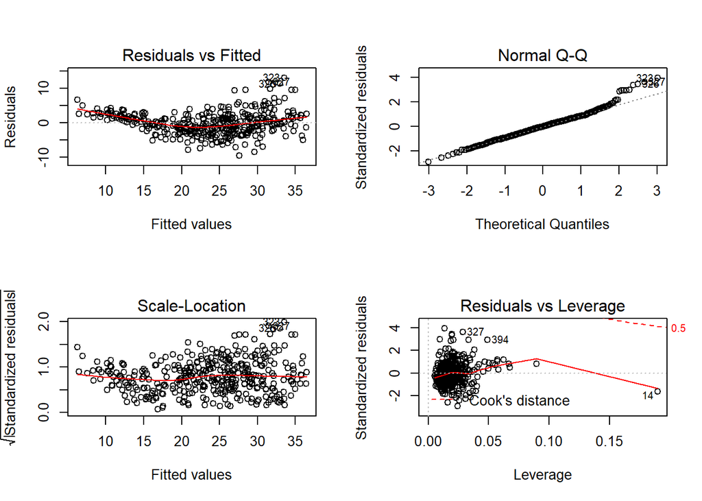

```r
par(mfrow=c(2,2))
plot(lm.fit)
```

*There does still seem to be a trend in the residuals plot, but it does look like a better fit than the simple linear regression using just horsepower as a predictor.*

*The plots reveal the 327<sup>th</sup> and 394<sup>th</sup> observations to be outliers and the 14<sup>th</sup> observation to be a high leverage point.*

5. Use the * and **:** symbols to fit linear regression models with interaction effects. Do any interactions appear to be statistically significant?

```r
lm.fit = lm(mpg ~ displacement*weight + displacement*year + displacement*origin + weight*year + weight*origin + year*origin, data = Auto)
summary(lm.fit)
```

```
##
## Call:
## lm(formula = mpg ~ displacement * weight + displacement * year +
##     displacement * origin + weight * year + weight * origin +
##     year * origin, data = Auto)
##
## Residuals:
##     Min      1Q  Median      3Q     Max
## -8.9244 -1.5779 -0.1339  1.2274 14.0364
##
## Coefficients:
##                       Estimate Std. Error t value Pr(>|t|)
## (Intercept)         -2.172e+01  2.449e+01  -0.887  0.37571
## displacement         2.377e-02  8.216e-02   0.289  0.77250
## weight              -6.472e-03  1.108e-02  -0.584  0.55947
## year                 9.586e-01  3.182e-01   3.012  0.00276 **
## origin              -5.630e+00  5.253e+00  -1.072  0.28453
## displacement:weight  1.814e-05  2.725e-06   6.657  9.6e-11 ***
## displacement:year   -1.446e-03  1.126e-03  -1.285  0.19971
## displacement:origin  1.545e-02  1.272e-02   1.215  0.22503
## weight:year         -2.067e-05  1.496e-04  -0.138  0.89019
## weight:origin       -1.275e-03  9.415e-04  -1.355  0.17628
## year:origin          9.324e-02  6.514e-02   1.431  0.15314
## ---
## Signif. codes:  0 '***' 0.001 '**' 0.01 '*' 0.05 '.' 0.1 ' ' 1
##
## Residual standard error: 2.944 on 386 degrees of freedom
## Multiple R-squared:  0.8621, Adjusted R-squared:  0.8585
## F-statistic: 241.3 on 10 and 386 DF,  p-value: < 2.2e-16
```

*In this fit, I used all of the predictors that had low p-values in the original multiple linear regression. I included an interaction term pairwise between each of those predictors. Surprisingly, very few of the resulting terms have low associated p-values. The overall model does have a low p-value though.*

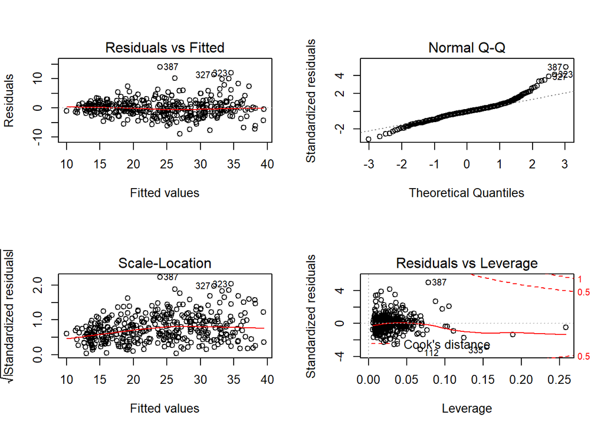

```r
par(mfrow=c(2,2))
plot(lm.fit)
```

*In this model, the residuals seem to be random across the fitted values, suggesting a better fit than the original regression.*

6. Try a few different transformations of the variables, such as log(X), $\sqrt{X}$, X<sup>2</sup>. Comment on your findings.

```r
lm.fit = lm(mpg~log(horsepower), data=Auto)
summary(lm.fit)
```

```
##
## Call:
## lm(formula = mpg ~ log(horsepower), data = Auto)
##
## Residuals:
##      Min       1Q   Median       3Q      Max
## -14.2299  -2.7818  -0.2322   2.6661  15.4695
##
## Coefficients:
##                 Estimate Std. Error t value Pr(>|t|)
## (Intercept)     108.6997     3.0496   35.64   <2e-16 ***
## log(horsepower) -18.5822     0.6629  -28.03   <2e-16 ***
## ---
## Signif. codes:  0 '***' 0.001 '**' 0.01 '*' 0.05 '.' 0.1 ' ' 1
##
## Residual standard error: 4.501 on 390 degrees of freedom
##   (5 observations deleted due to missingness)
## Multiple R-squared:  0.6683, Adjusted R-squared:  0.6675
## F-statistic: 785.9 on 1 and 390 DF,  p-value: < 2.2e-16
```

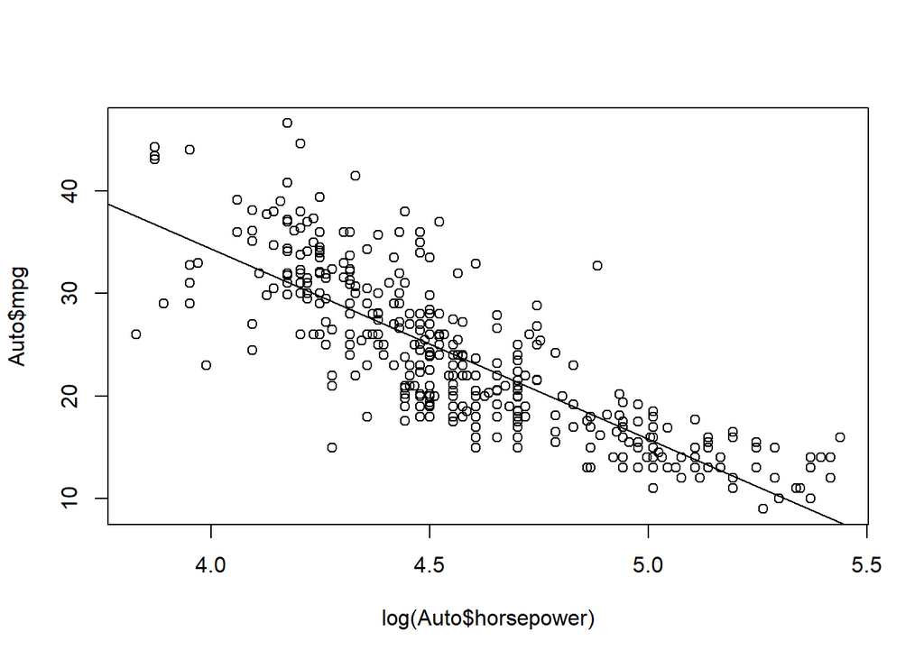

```r
plot(x = log(Auto$horsepower), y = Auto$mpg)
abline(lm.fit)
```

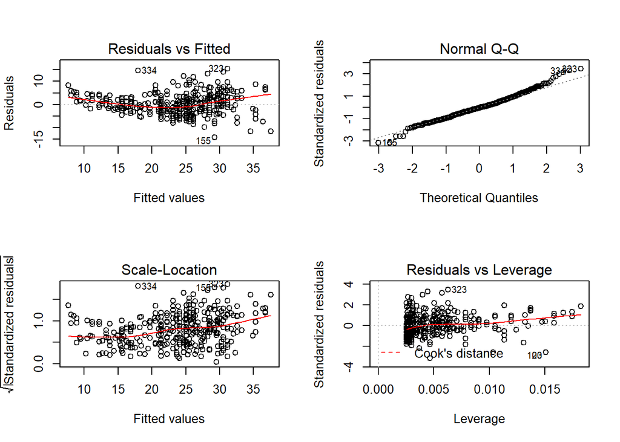

```r
par(mfrow=c(2,2))
plot(lm.fit)
```

*A logarithmic transform of the horsepower predictor makes a much better model for the fit from Exercise 9, but it still looks like it’s not a perfect model. Let’s take a look at adding that predictor to a model with the predictors that had low p-values in 9.c.ii (displacement, weight, year, and origin).*

```r
lm.fit = lm(mpg ~ log(horsepower) + displacement + weight + year + origin, data = Auto)
summary(lm.fit)
```

```
##
## Call:
## lm(formula = mpg ~ log(horsepower) + displacement + weight +
##     year + origin, data = Auto)
##
## Residuals:
##     Min      1Q  Median      3Q     Max
## -8.8091 -1.9147 -0.1579  1.8765 12.5231
##
## Coefficients:
##                   Estimate Std. Error t value Pr(>|t|)
## (Intercept)      9.2041460  6.1865858   1.488  0.13763
## log(horsepower) -6.4123276  1.1128868  -5.762  1.7e-08 ***
## displacement     0.0166532  0.0049675   3.352  0.00088 ***
## weight          -0.0054967  0.0005671  -9.693  < 2e-16 ***
## year             0.7163068  0.0488094  14.676  < 2e-16 ***
## origin           1.5005416  0.2608891   5.752  1.8e-08 ***
## ---
## Signif. codes:  0 '***' 0.001 '**' 0.01 '*' 0.05 '.' 0.1 ' ' 1
##
## Residual standard error: 3.215 on 386 degrees of freedom
##   (5 observations deleted due to missingness)
## Multiple R-squared:  0.8325, Adjusted R-squared:  0.8303
## F-statistic: 383.7 on 5 and 386 DF,  p-value: < 2.2e-16
```

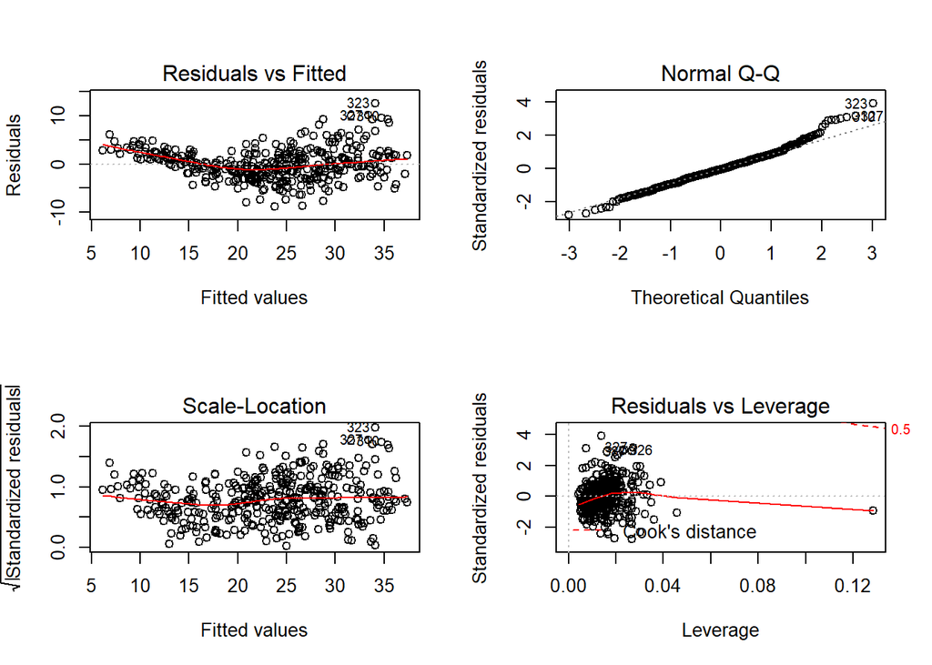

```r
par(mfrow=c(2,2))
plot(lm.fit)
```

*Even though all of the p-values are low, there is still an apparent pattern in the residuals plot. This pattern suggests that this model contains some bias error.*

# Exercise 10

This questions should be answered using the **Carseats** data set.

```r
library(ISLR)
?Carseats
```

```
## starting httpd help server ...
```

```
##  done
```

1. Fit a multiple regression model to predict **Sales** using **Price**, **Urban**, and **US**.

```r
lm.fit = lm(Sales ~ Price + Urban + US, data = Carseats)
summary(lm.fit)
```

```
##
## Call:
## lm(formula = Sales ~ Price + Urban + US, data = Carseats)
##
## Residuals:
##     Min      1Q  Median      3Q     Max
## -6.9206 -1.6220 -0.0564  1.5786  7.0581
##
## Coefficients:
##              Estimate Std. Error t value Pr(>|t|)
## (Intercept) 13.043469   0.651012  20.036  < 2e-16 ***
## Price       -0.054459   0.005242 -10.389  < 2e-16 ***
## UrbanYes    -0.021916   0.271650  -0.081    0.936
## USYes        1.200573   0.259042   4.635 4.86e-06 ***
## ---
## Signif. codes:  0 '***' 0.001 '**' 0.01 '*' 0.05 '.' 0.1 ' ' 1
##
## Residual standard error: 2.472 on 396 degrees of freedom
## Multiple R-squared:  0.2393, Adjusted R-squared:  0.2335
## F-statistic: 41.52 on 3 and 396 DF,  p-value: < 2.2e-16
```

2. Provide an interpretation of each coefficient in the model. Be careful – some of the variables in the model are qualitative!

```r
contrasts(Carseats$Urban)
```

```
##     Yes
## No    0
## Yes   1
```

```r
contrasts(Carseats$US)
```

```
##     Yes
## No    0
## Yes   1
```

*The (Intercept) coefficient of 13.043 means that if the carseats are free and the store is in a rural area outside of the US, then the predicted unit sales for the location is 13,043 carseats. Of course, that predictor value is unrealistic because the store would not just give away carseats.*

*The USYes coefficient of 1.201 means that, on average, US stores sell about 1,201 more carseats than stores outside the US.*

3. Write out the model in equation form, being careful to handle the qualitative variables properly.

$Sales = \begin{cases} 14.222126 - 0.054459 Price & \text{Urban store in the US} \\ 14.244042 - 0.054459 Price & \text{Rural store in the US} \\ 13.021553 - 0.054459 Price & \text{Urban store outside the US} \\ 13.043469 - 0.054459 Price & \text{Rural store outside the US} \end{cases}$

4. For which of the predictors can you reject the null hypothesis $H_0: \beta_j = 0$?

*For Price and US, we may reject the null hypothesis.*

5. On the basis of your response to the previous question, fit a smaller model that only uses the predictors for which there is evidence of association with the outcome.

```r
lm.fit2 = lm(Sales ~ Price + US, data = Carseats)
summary(lm.fit2)
```

```
##
## Call:
## lm(formula = Sales ~ Price + US, data = Carseats)
##
## Residuals:
##     Min      1Q  Median      3Q     Max
## -6.9269 -1.6286 -0.0574  1.5766  7.0515
##
## Coefficients:
##             Estimate Std. Error t value Pr(>|t|)
## (Intercept) 13.03079    0.63098  20.652  < 2e-16 ***
## Price       -0.05448    0.00523 -10.416  < 2e-16 ***
## USYes        1.19964    0.25846   4.641 4.71e-06 ***
## ---
## Signif. codes:  0 '***' 0.001 '**' 0.01 '*' 0.05 '.' 0.1 ' ' 1
##
## Residual standard error: 2.469 on 397 degrees of freedom
## Multiple R-squared:  0.2393, Adjusted R-squared:  0.2354
## F-statistic: 62.43 on 2 and 397 DF,  p-value: < 2.2e-16
```

6. How well do the models in (a) and (e) fit the data?

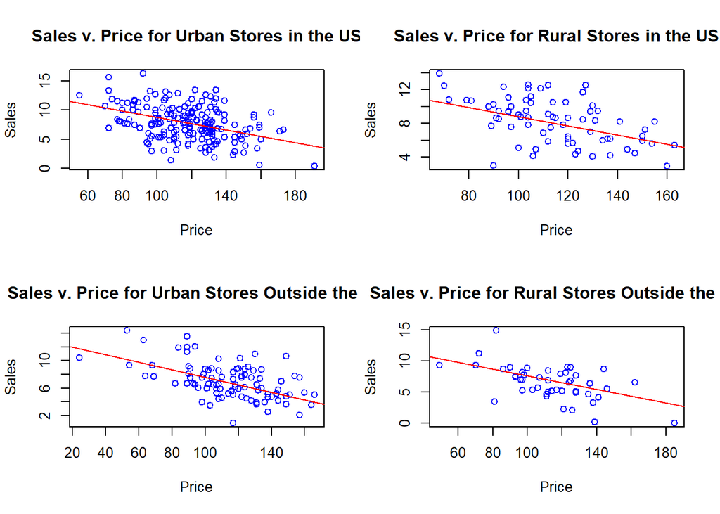

```r
inUs = Carseats[Carseats$US == 'Yes',]
outUs = Carseats[Carseats$US == 'No',]
ruralInUS = inUs[inUs$Urban == 'No',]
ruralOutUS = outUs[outUs$Urban == 'No',]
urbanInUS = inUs[inUs$Urban == 'Yes',]
urbanOutUS = outUs[outUs$Urban == 'Yes',]

# Plot the first fit
par(mfrow=c(2,2))
plot(urbanInUS$Price, urbanInUS$Sales, xlab = 'Price', ylab = 'Sales', main = 'Sales v. Price for Urban Stores in the US', col = 'blue')
abline(14.222126, -0.054459, col = 'red')
plot(ruralInUS$Price, ruralInUS$Sales, xlab = 'Price', ylab = 'Sales', main = 'Sales v. Price for Rural Stores in the US', col = 'blue')
abline(14.244042, -0.054459, col = 'red')
plot(urbanOutUS$Price, urbanOutUS$Sales, xlab = 'Price', ylab = 'Sales', main = 'Sales v. Price for Urban Stores Outside the US', col = 'blue')
abline(13.021553, -0.054459, col = 'red')
plot(ruralOutUS$Price, ruralOutUS$Sales, xlab = 'Price', ylab = 'Sales', main = 'Sales v. Price for Rural Stores Outside the US', col = 'blue')
abline(13.043469, -0.054459, col = 'red')
```

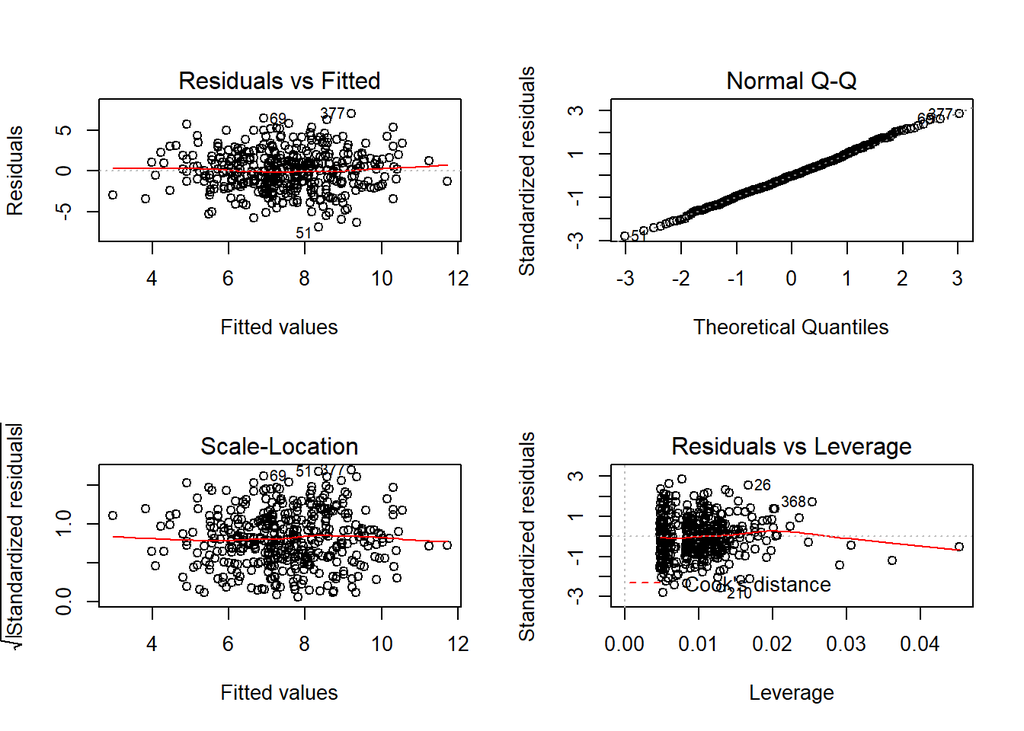

```r
par(mfrow=c(2,2))
plot(lm.fit)
```

*For the first model using Price, Urban, and US as predictors for Sales, there may not be a trend in the residuals, but as you can see from the plots above, as well as the R<sup>2</sup> value, the linear model here does not fit the data very well.*

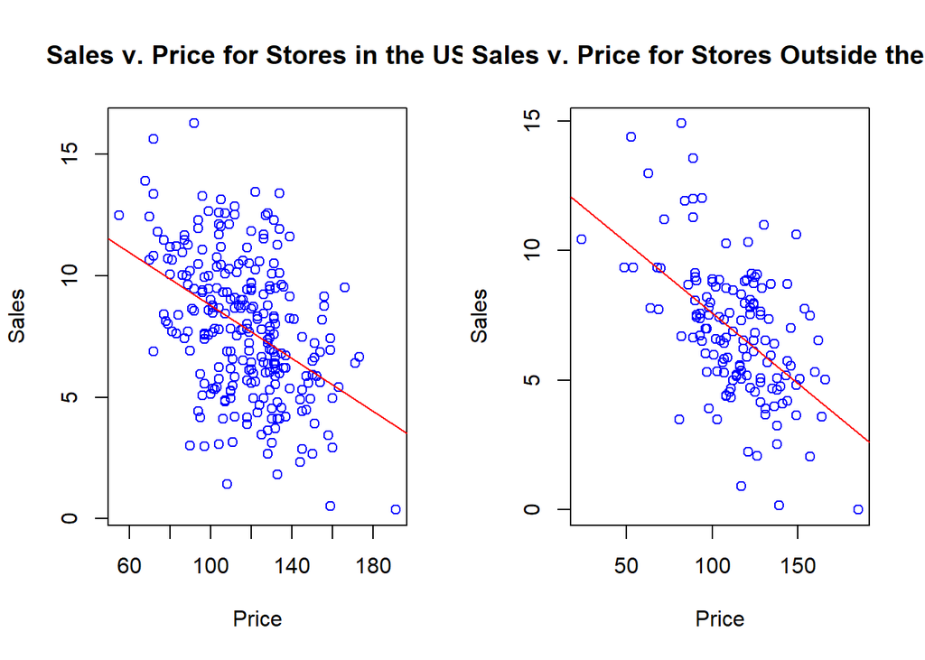

```r
# Plot the first fit
par(mfrow=c(1,2))
plot(inUs$Price, inUs$Sales, xlab = 'Price', ylab = 'Sales', main = 'Sales v. Price for Stores in the US', col = 'blue')
abline(13.03079 + 1.19964, -0.05448, col = 'red')
plot(outUs$Price, outUs$Sales, xlab = 'Price', ylab = 'Sales', main = 'Sales v. Price for Stores Outside the US', col = 'blue')
abline(13.03079, -0.05448, col = 'red')
```

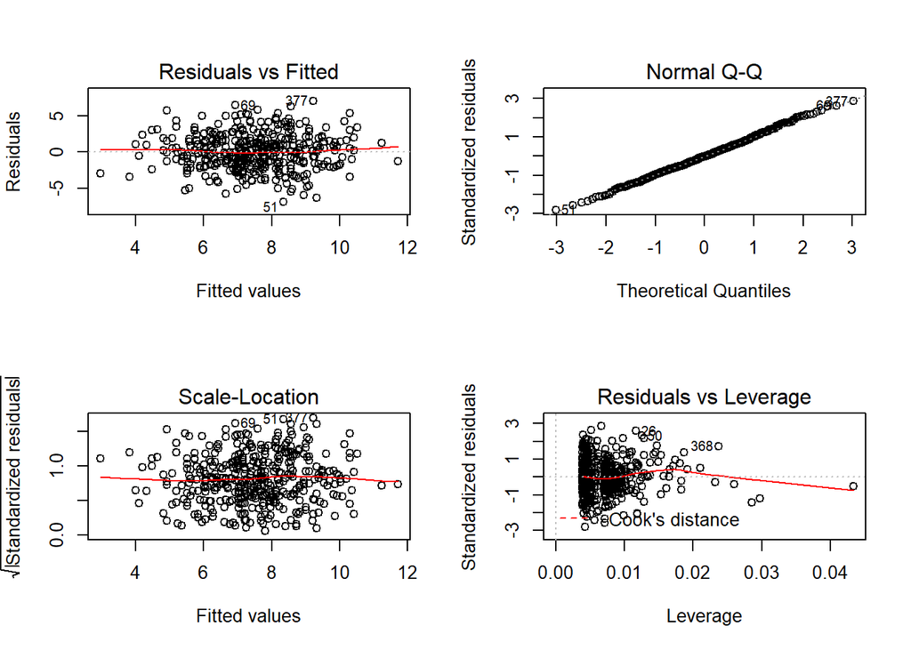

```r
par(mfrow=c(2,2))
plot(lm.fit2)
```

*For the second model using Price and US as predictors for Sales, the residuals again seem to have no pattern. However, there is still a low R<sup>2</sup> value and the regression looks like it only a slightly better fit for the data.*

7. Using the model from (e), obtain 95% confidence intervals for the coefficient(s).

```r
confint(lm.fit2)
```

```
##                   2.5 %      97.5 %
## (Intercept) 11.79032020 14.27126531
## Price       -0.06475984 -0.04419543
## USYes        0.69151957  1.70776632
```

*The confidence intervals are fairly wide for the estimated coefficients.*

8. Is there evidence of outliers or high leverage observations in the model from (e)?

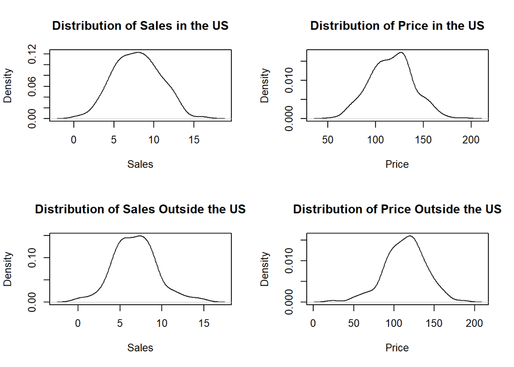

```r
par(mfrow=c(2,2))
plot(density(inUs$Sales), xlab = 'Sales', ylab = 'Density', main = 'Distribution of Sales in the US')
plot(density(inUs$Price), xlab = 'Price', ylab = 'Density', main = 'Distribution of Price in the US')
plot(density(outUs$Sales), xlab = 'Sales', ylab = 'Density', main = 'Distribution of Sales Outside the US')
plot(density(outUs$Price), xlab = 'Price', ylab = 'Density', main = 'Distribution of Price Outside the US')
```

*You can see that the Price distribution in the US is skewed right. The observations with Price > $175 for stores in the US may be considered high leverage points. The Price distribution outside the US is skewed left. The observations with Price < $50 for stores outside the US may be considered high leverage points. There don’t seem to be any outliers for stores within the US, but the distribution of Sales for stores outside the US has long tails. I would consider any of the observations with Sales > 15 for stores outside the US to be outliers. I don’t know what the meaning behind negative sales is, but it seems like any observation with Sales < 0 for stores outside the US could be considered outliers.*

```r
# High leverage points
Carseats[(Carseats$Price > 175 & Carseats$US == 'Yes') | (Carseats$Price < 50) & Carseats$US == 'No', c('Sales', 'Price', 'US')]
```

```
##     Sales Price  US
## 43  10.43    24  No
## 126  9.34    49  No
## 166  0.37   191 Yes
```

*So it looks like we have 3 points that could be considered high leverage.*

```r
# Outliers
Carseats[Carseats$US == 'No' & (Carseats$Sales > 15 | Carseats$Sales < 0), c('Sales', 'Price', 'US')]
```

```
## [1] Sales Price US
## <0 rows> (or 0-length row.names)
```

*I guess the plot is a little misleading, because there aren’t actually any stores outside the US that have more than 15 or less than 0 sales. Therefore, I would say that there aren’t really any outliers in the data.*

*Another approach to determining outliers and high leverage points, which is more applicable to models with more predictors, is to use the* hatvalues *and* rstandard *functions in R.*

```r
p = 2
n = length(Carseats)
leverage = hatvalues(lm.fit2)
print(sum(leverage > (p + 1)/n))
```

```
## [1] 0
```

```r
studentizedResiduals = rstudent(lm.fit2)
print(sum(studentizedResiduals >= 3))
```

```
## [1] 0
```

*According to the definition of an outlier from section 3.3.3, there are no outliers in the data.*

# Exercise 11

In this problem we will investigate the t-statistic for the null hypothesis: $H_0: \beta = 0$ in simple linear regression without an intercept. To begin, we generate a predictor **x** and a response **y** as follows.

```
> set.seed(1)
> x=rnorm(100)
> y=2*x+rnorm(100)
```

```r
set.seed(1)
x = rnorm(100)
y = 2 * x + rnorm(100)
```

1. Perform a simple linear regression of **y** onto **x**, *without* an intercept. Report the coefficient estimate $\hat{\beta}$, the standard error this coefficient estimate, its standard error, and the corresponding t-statistic and p-values associated with the null hypothesis $H_0: \beta = 0$. Comment on these results. (You can perform regression without an intercept using the command **lm(y~x+0)**.)

```r
lm.fit = lm(y ~ x + 0)
summary(lm.fit)
```

```
##
## Call:
## lm(formula = y ~ x + 0)
##
## Residuals:
##     Min      1Q  Median      3Q     Max
## -1.9154 -0.6472 -0.1771  0.5056  2.3109
##
## Coefficients:
##   Estimate Std. Error t value Pr(>|t|)
## x   1.9939     0.1065   18.73   <2e-16 ***
## ---
## Signif. codes:  0 '***' 0.001 '**' 0.01 '*' 0.05 '.' 0.1 ' ' 1
##
## Residual standard error: 0.9586 on 99 degrees of freedom
## Multiple R-squared:  0.7798, Adjusted R-squared:  0.7776
## F-statistic: 350.7 on 1 and 99 DF,  p-value: < 2.2e-16
```

*The true relationship is y = 2x. The linear fit is very close at y = 1.9939x.*

4. For the regression of Y onto X without an intercept, the t-statistic for $H_0: \beta = 0$ takes the form $\frac{\hat{\beta}}{SE(\hat{\beta})}$, where $\hat{\beta}$ is given by (3.38), and where
   $$SE(\hat{\beta}) = \sqrt{\frac{\sum^n_{i=1}(y_i - x_i \hat{\beta})^2}{(n - 1) \sum^n_{i'=1}x^2_{i'}}}$$
   . (These formulas are slightly different from those given in Sections 3.1.1 and 3.1.2, since here we are performing regression without an intercept.) Show algebraically, and confirm numerically in R, that the t-statistic can be written as
   $$\frac{(\sqrt{n - 1}) \sum^n_{i=1}x_i y_i}{\sqrt{\sum^n_{i=1} x^2_i \sum^n_{i'=1}y^2_{i'} - (\sum^n_{i'=1}x_{i'}y_{i'})^2}}$$
   .

```r
n = 100
beta = as.numeric(coef(lm.fit)['x'])
se = sqrt(sum((y - x * beta)^2) / ((n - 1) * sum(x*x)))
tstat1 = beta / se
tstat2 = sqrt(n - 1) * sum(x * y) / sqrt(sum(x*x) * sum(y * y) - (sum(x*y))^2)
tstat1 == tstat2
```

```
## [1] TRUE
```

*The values are numerically equal in R.*

*Proof for algebraic congruency:*

*First, we must define* $\hat{\beta}$ *for a simple linear regression with no intercept.*

*Typically,* $\hat{\beta} = \frac{\sum^n_{i=1} (x_i - \bar{x})(y_i - \bar{y})}{\sum^n_{i=1} (x_i - \bar{x})^2}$ *because we want to find what change in y results from a change in x and we must center those deltas around the means to account for* $\beta_0$. *However, if we assume that* $\beta_0 = 0$, *then we can center those deltas around 0. Therefore,* $\hat{\beta} = \frac{\sum^n_{i=1}x_i y_i}{\sum^n_{i=1}x^2_i}$ *for a simple linear regression with no intercept.*

*Plugging that into the equation…*

$$\frac{\hat{\beta}}{SE(\hat{\beta})} = \frac{\sum^n_{i=1}x_i y_i}{\sum^n_{i=1}x^2_i} \sqrt{\frac{(n - 1) \sum^n_{i=1} x^2_i}{\sum^n_{i=1} (y_i - x_i \hat{\beta})^2}}$$
$$= \frac{\sqrt{n-1}\sum^n_{i=1}x_i y_i}{\sqrt{\sum^n_{i=1}x^2_i \sum^n_{i=1}(y_i - x_i \hat{\beta})^2}}$$
$$= \frac{\sqrt{n-1}\sum^n_{i=1}x_i y_i}{\sqrt{\sum^n_{i=1}x^2_i \sum^n_{i=1}(y_i^2 - 2 \hat{\beta} y_i x_i + \hat{\beta}^2 x_i^2)}}$$
$$= \frac{\sqrt{n-1}\sum^n_{i=1}x_i y_i}{\sqrt{\sum^n_{i=1}x^2_i \sum^n_{i=1} y_i^2 - (\sum^n_{i=1}x^2_i) \hat{\beta} (2 y_i x_i - \hat{\beta} x_i^2)}}$$
$$= \frac{\sqrt{n-1}\sum^n_{i=1}x_i y_i}{\sqrt{\sum^n_{i=1}x^2_i \sum^n_{i=1} y_i^2 - (\sum^n_{i=1}x^2_i) (\frac{\sum^n_{i=1}x_i y_i}{\sum^n_{i=1}x^2_i}) (2 \sum^n_{i=1} y_i x_i - (\frac{\sum^n_{i=1}x_i y_i}{\sum^n_{i=1}x^2_i}) x_i^2)}}$$
$$= \frac{\sqrt{n-1}\sum^n_{i=1}x_i y_i}{\sqrt{\sum^n_{i=1}x^2_i \sum^n_{i=1} y_i^2 - (\sum^n_{i=1}x_i y_i) (2 \sum^n_{i=1} y_i x_i - \sum^n_{i=1}x_i y_i)}}$$
$$= \frac{\sqrt{n-1}\sum^n_{i=1}x_i y_i}{\sqrt{\sum^n_{i=1}x^2_i \sum^n_{i=1} y_i^2 - (\sum^n_{i=1}x_i y_i) (\sum^n_{i=1}x_i y_i)}}$$
$$= \frac{\sqrt{n-1}\sum^n_{i=1}x_i y_i}{\sqrt{\sum^n_{i=1}x^2_i \sum^n_{i=1} y_i^2 - (\sum^n_{i=1}x_i y_i)^2}}$$

5. Using the results from (d), argue that the t-statistic for the regression of **y** onto **x** is the same as the t-statistic for the regression of **x** onto **y**.

*If you use* y *as the predictor and* x *as the response, the equation in (e) is the same.*

$$\frac{\sqrt{n-1}\sum^n_{i=1}y_i x_i}{\sqrt{\sum^n_{i=1}y^2_i \sum^n_{i=1} x_i^2 - (\sum^n_{i=1}y_i
x_i)^2}} = \frac{\sqrt{n-1}\sum^n_{i=1}x_i y_i}{\sqrt{\sum^n_{i=1}x^2_i \sum^n_{i=1} y_i^2 - (\sum^n_{i=1}x_i y_i)^2}}$$

*Therefore, the t-statistics are the same for both regressions.*

6. In R, show that when regression is performed *with* an intercept, the t-statistic for $H_0: \beta_1 = 0$ is the same for the regression of **y** onto **x** as it is for the regression of **x** onto **y**.

```r
getT <- function(x, y){
  n = length(x)
  lm.fit = lm(y ~ x)
  beta1 = as.numeric(coef(lm.fit)['x'])
  RSS = sum((y - predict(lm.fit, data.frame(x=x)))^2)
  RSE = sqrt(RSS / (n - 2))
  SE = sqrt(RSE^2 / sum((x - mean(x))^2))
  return(beta1/SE)
}
getT(x,y)
```

```
## [1] 18.5556
```

```r
getT(y,x)
```

```
## [1] 18.5556
```

*You can see that the t-statistic is the same for both the regression of* y *onto* x *and for* x *onto* y.

# Exercise 12

This problem involves simple linear regression without an intercept.

1. Recall that the coefficient estimate $\hat{\beta}$ for the linear regression of Y onto X without an intercept is given by (3.38). Under what circumstance is the coefficient estimate for the regression of X onto Y the same as the coefficient estimate for the regression of Y onto X?

*For a simple linear regression with no intercept,* $\hat{\beta} = \frac{\sum^n_{i=1}x_i y_i}{\sum^n_{i=1}x^2_i}$ *Therefore, the coefficient estimate for the regression of X onto Y is the same as the coefficient estimate for the regression of Y onto X iff* $\sum^n_{i=1}x^2_i = \sum^n_{i=1}y^2_i$

2. Generate an example in R with *n* = 100 observations in which the coefficient estimate for the regression X onto Y is *different from* the coefficient estimate for the regression onto X.

```r
y = 1:100 * 2
x = 1:100 - 4
```

```r
summary(lm(y~x+0))
```

```
##
## Call:
## lm(formula = y ~ x + 0)
##
## Residuals:
##     Min      1Q  Median      3Q     Max
## -3.9219 -0.8483  2.2253  5.2989  8.3726
##
## Coefficients:
##   Estimate Std. Error t value Pr(>|t|)
## x 2.124186   0.007748   274.2   <2e-16 ***
## ---
## Signif. codes:  0 '***' 0.001 '**' 0.01 '*' 0.05 '.' 0.1 ' ' 1
##
## Residual standard error: 4.241 on 99 degrees of freedom
## Multiple R-squared:  0.9987, Adjusted R-squared:  0.9987
## F-statistic: 7.516e+04 on 1 and 99 DF,  p-value: < 2.2e-16
```

```r
summary(lm(x~y+0))
```

```
##
## Call:
## lm(formula = x ~ y + 0)
##
## Residuals:
##     Min      1Q  Median      3Q     Max
## -3.9403 -2.4627 -0.9851  0.4925  1.9701
##
## Coefficients:
##   Estimate Std. Error t value Pr(>|t|)
## y 0.470149   0.001715   274.2   <2e-16 ***
## ---
## Signif. codes:  0 '***' 0.001 '**' 0.01 '*' 0.05 '.' 0.1 ' ' 1
##
## Residual standard error: 1.995 on 99 degrees of freedom
## Multiple R-squared:  0.9987, Adjusted R-squared:  0.9987
## F-statistic: 7.516e+04 on 1 and 99 DF,  p-value: < 2.2e-16
```

3. Generate an example in R with *n* = 100 observations in which the coefficient estimate for the regression of X onto Y is *the same as* the coefficient estimate for the regression of Y onto X.

```r
x = 1:100
y = 1:100 * -1
```

```r
summary(lm(y~x+0))
```

```
##
## Call:
## lm(formula = y ~ x + 0)
##
## Residuals:
##        Min         1Q     Median         3Q        Max
## -1.294e-14 -2.218e-15 -2.900e-17  2.094e-15  3.082e-13
##
## Coefficients:
##     Estimate Std. Error    t value Pr(>|t|)
## x -1.000e+00  5.379e-17 -1.859e+16   <2e-16 ***
## ---
## Signif. codes:  0 '***' 0.001 '**' 0.01 '*' 0.05 '.' 0.1 ' ' 1
##
## Residual standard error: 3.129e-14 on 99 degrees of freedom
## Multiple R-squared:      1,  Adjusted R-squared:      1
## F-statistic: 3.457e+32 on 1 and 99 DF,  p-value: < 2.2e-16
```

```r
summary(lm(x~y+0))
```

```
##
## Call:
## lm(formula = x ~ y + 0)
##
## Residuals:
##        Min         1Q     Median         3Q        Max
## -3.082e-13 -2.094e-15  2.900e-17  2.218e-15  1.294e-14
##
## Coefficients:
##     Estimate Std. Error    t value Pr(>|t|)
## y -1.000e+00  5.379e-17 -1.859e+16   <2e-16 ***
## ---
## Signif. codes:  0 '***' 0.001 '**' 0.01 '*' 0.05 '.' 0.1 ' ' 1
##
## Residual standard error: 3.129e-14 on 99 degrees of freedom
## Multiple R-squared:      1,  Adjusted R-squared:      1
## F-statistic: 3.457e+32 on 1 and 99 DF,  p-value: < 2.2e-16
```

# Exercise 13

In this exercise you will create some simulated data and will fit simple linear regression models to it. Make sure to use **set.seed(1)** prior to starting part (a) to ensure consitent results.

```r
set.seed(1)
```

1. Using the **rnorm()** function, create a vector, **x**, containing 100 observations drawn from a *N(0,1)* distribution. This represents a feature, X.

```r
x = rnorm(100)
```

2. Using the **rnorm()** function, create a vector, **eps**, containing 100 observations drawn from a *N(0,0.25)* distribution (i.e. a normal distribution with mean zero and variance 0.25).

```r
eps = rnorm(100, sd = .25)
```

3. Using **x** and **eps**, generate a vector **y** according to the model $Y = -1 + 0.5 X + \epsilon$. What is the length of the vector **y**? What are the values of $\beta_0$ and $\beta_1$ in this linear model?

```r
y = -1 + .5 * x + eps
length(y)
```

```
## [1] 100
```

*y is a vector with 100 observations. The true parameters of the model are:* $\beta_0 = -1$ *and* $\beta_1 = 0.5$.

4. Create a scatterplot displaying the relationship between **x** and **y**. COmment on what you observe.

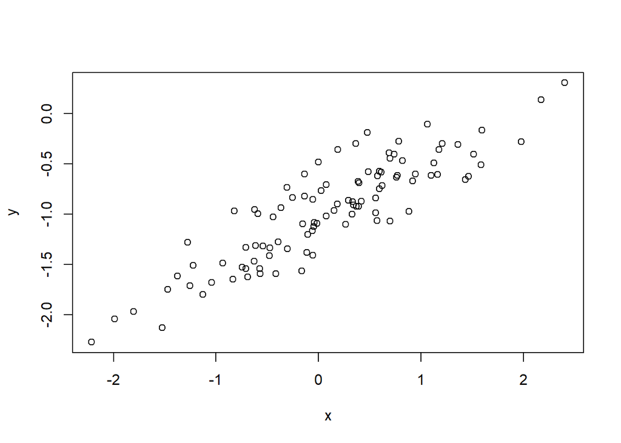

```r
plot(x,y)
```

*There is clearly a relationship between* x *and* y *with a little bit of noise.*

5. Fit a least squares linear model to predict **y** using **x**. Comment on the model obtained. How do the estimates $\hat{\beta_0}$ and $\hat{\beta_1}$ compare to the true values of $\beta_0$ and $\beta_1$?

```r
lm.fit = lm(y ~ x)
summary(lm.fit)
```

```
##
## Call:
## lm(formula = y ~ x)
##
## Residuals:
##      Min       1Q   Median       3Q      Max
## -0.46921 -0.15344 -0.03487  0.13485  0.58654
##
## Coefficients:
##             Estimate Std. Error t value Pr(>|t|)
## (Intercept) -1.00942    0.02425  -41.63   <2e-16 ***
## x            0.49973    0.02693   18.56   <2e-16 ***
## ---
## Signif. codes:  0 '***' 0.001 '**' 0.01 '*' 0.05 '.' 0.1 ' ' 1
##
## Residual standard error: 0.2407 on 98 degrees of freedom
## Multiple R-squared:  0.7784, Adjusted R-squared:  0.7762
## F-statistic: 344.3 on 1 and 98 DF,  p-value: < 2.2e-16
```

*The estimated parameters for the model are:* $\hat{\beta_0} = -1.00942$ *and* $\hat{\beta_1} = 0.49973$. *These values are very close to the true relationship.*

6. Display the least squares line on the scatterplot obtained in (d). Draw the population regression line on the plot, in a different color. Use the **legend()** command to create an appropriate legend.

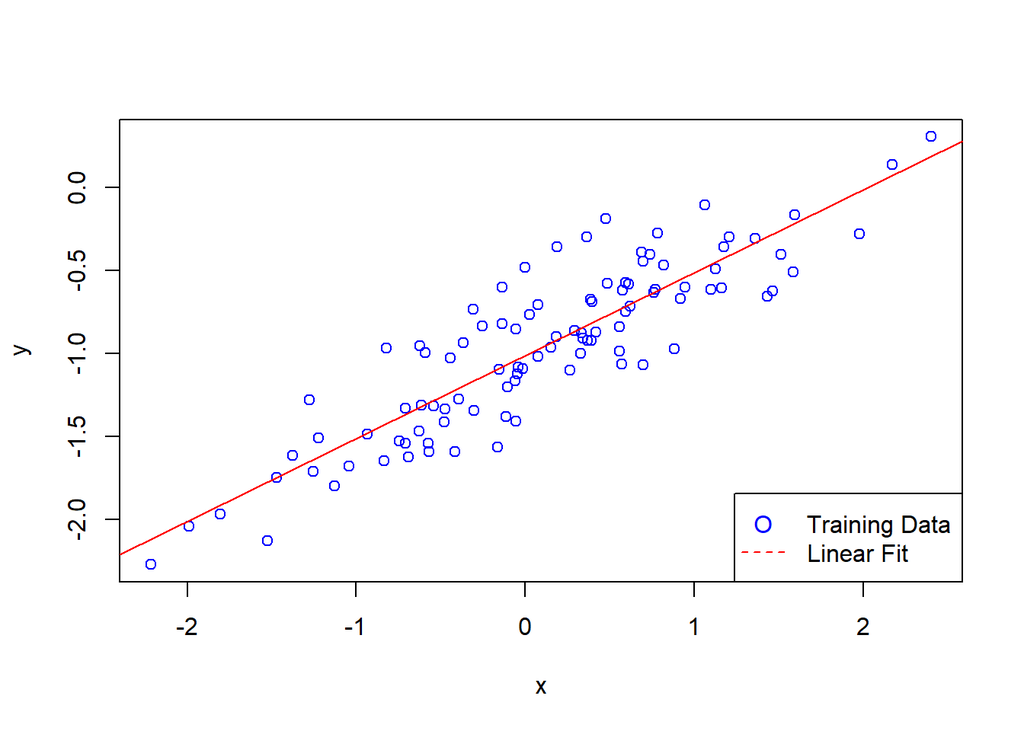

```r
plot(x,y, col = 'blue')
abline(lm.fit, col = 'red')
legend('bottomright', legend = c('Training Data', 'Linear Fit'), lty = c(NA,2), pch = c('O', NA), col = c('blue', 'red'))
```

7. Now fit a polynomial regression model that predicts **y** using **x** and **x<sup>2</sup>**. Is there evidence that the quadratic term improves the model fit? Explain your answer.

```r
lm.fit2 = lm(y~I(x^2)+x+0)
```

```r
summary(lm.fit2)
```

```
##
## Call:
## lm(formula = y ~ I(x^2) + x + 0)
##
## Residuals:
##     Min      1Q  Median      3Q     Max
## -1.4705 -1.0175 -0.7383 -0.4404  1.6750
##
## Coefficients:
##        Estimate Std. Error t value Pr(>|t|)
## I(x^2) -0.43595    0.06134  -7.107 1.93e-10 ***
## x       0.47742    0.09522   5.014 2.37e-06 ***
## ---
## Signif. codes:  0 '***' 0.001 '**' 0.01 '*' 0.05 '.' 0.1 ' ' 1
##
## Residual standard error: 0.8452 on 98 degrees of freedom
## Multiple R-squared:  0.4008, Adjusted R-squared:  0.3886
## F-statistic: 32.78 on 2 and 98 DF,  p-value: 1.26e-11
```

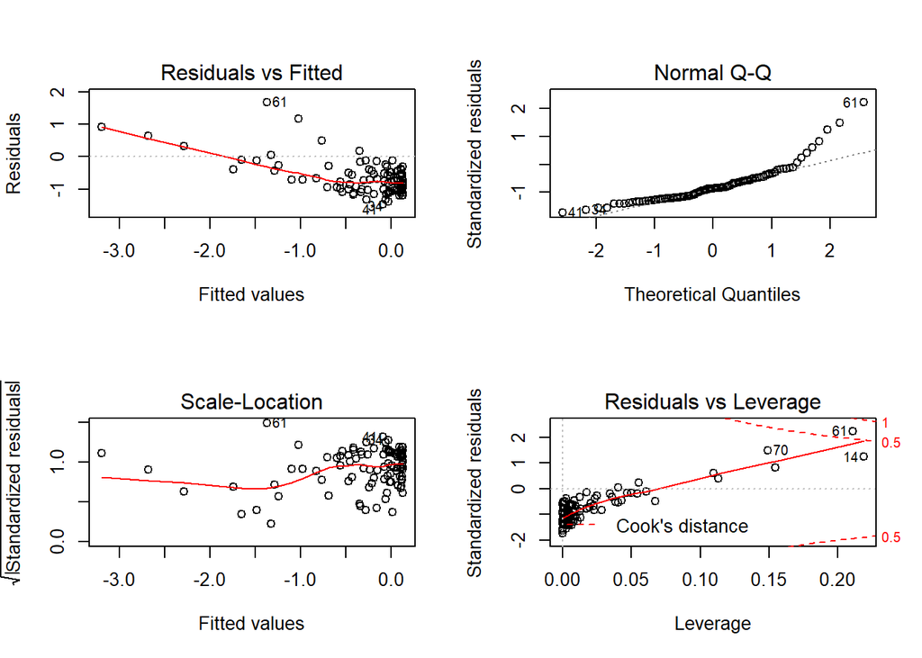

```r
par(mfrow=c(2,2))
plot(lm.fit2)
```

8. Repeat (a)-(f) after modifying the data generation process in such a way that there is *less* noise in the data. The model from (c) should remain the same. You can do this by decreasing the variance of the normal distribution used to generate the error term $\epsilon$ in (b). Describe your results.

```r
y_less_noise = -1 + .5 * x + rnorm(100, sd = .1)
lm.fit_less_noise = lm(y_less_noise ~ x)
```

```r
summary(lm.fit_less_noise)
```

```
##
## Call:
## lm(formula = y_less_noise ~ x)
##
## Residuals:
##       Min        1Q    Median        3Q       Max
## -0.291411 -0.048230 -0.004533  0.064924  0.264157
##
## Coefficients:
##             Estimate Std. Error t value Pr(>|t|)
## (Intercept) -0.99726    0.01047  -95.25   <2e-16 ***
## x            0.50212    0.01163   43.17   <2e-16 ***
## ---
## Signif. codes:  0 '***' 0.001 '**' 0.01 '*' 0.05 '.' 0.1 ' ' 1
##
## Residual standard error: 0.1039 on 98 degrees of freedom
## Multiple R-squared:  0.9501, Adjusted R-squared:  0.9495
## F-statistic:  1864 on 1 and 98 DF,  p-value: < 2.2e-16
```

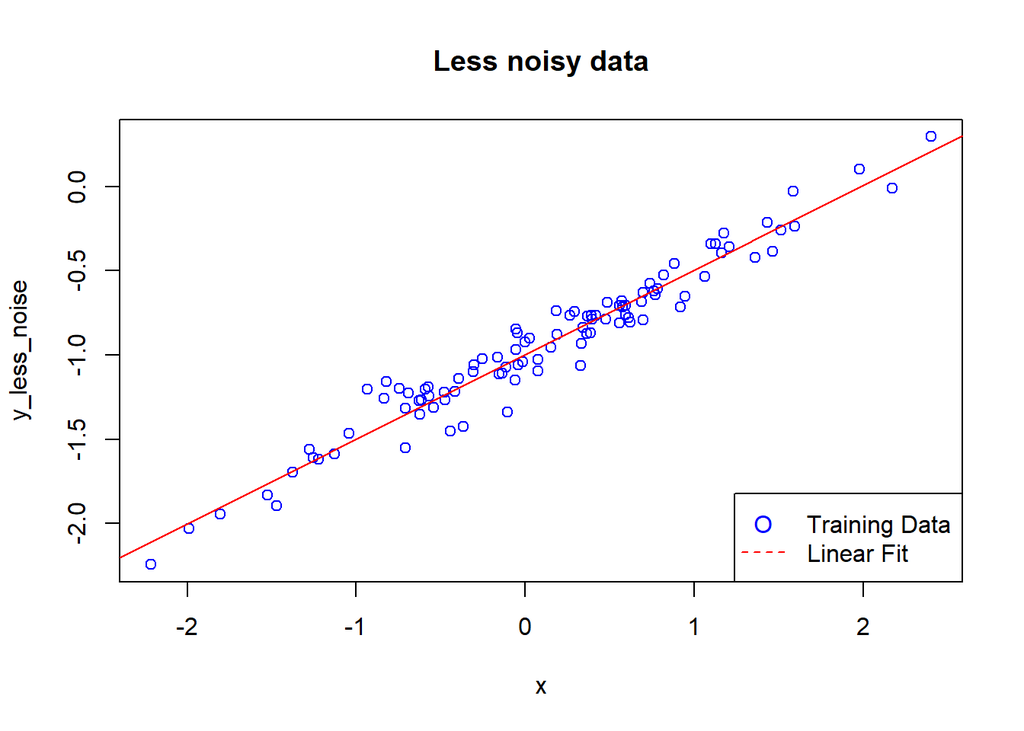

```r
plot(x,y_less_noise, col = 'blue', main = 'Less noisy data')
abline(lm.fit_less_noise, col = 'red')
legend('bottomright', legend = c('Training Data', 'Linear Fit'), lty = c(NA,2), pch = c('O', NA), col = c('blue', 'red'))
```

*You can see less variance in the training data and a tighter fit to the estimated model.*

1. Repeat (a)-(f) after modifying the generation process in such a way that there is *more* noise in the data. Describe your results.

```r
y_more_noise = -1 + .5 * x + rnorm(100, sd = .4)
lm.fit_more_noise = lm(y_more_noise ~ x)
```

```r
summary(lm.fit_more_noise)
```

```
##
## Call:
## lm(formula = y_more_noise ~ x)
##
## Residuals:
##     Min      1Q  Median      3Q     Max
## -1.0065 -0.2181 -0.0151  0.2692  0.7516
##
## Coefficients:
##             Estimate Std. Error t value Pr(>|t|)
## (Intercept) -0.97693    0.04011  -24.36   <2e-16 ***
## x            0.47773    0.04455   10.72   <2e-16 ***
## ---
## Signif. codes:  0 '***' 0.001 '**' 0.01 '*' 0.05 '.' 0.1 ' ' 1
##
## Residual standard error: 0.3982 on 98 degrees of freedom
## Multiple R-squared:  0.5398, Adjusted R-squared:  0.5351
## F-statistic:   115 on 1 and 98 DF,  p-value: < 2.2e-16
```

*Both the estimated parameters are farther from their true values.*

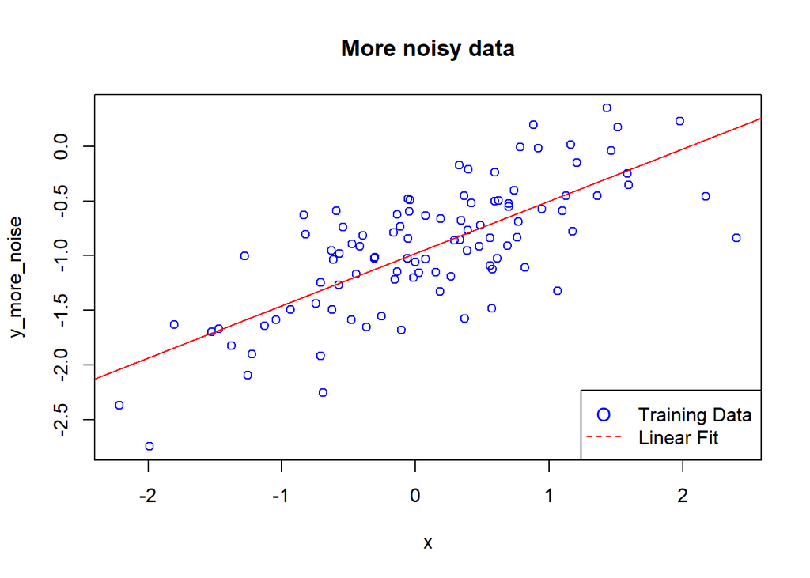

```r
plot(x,y_more_noise, col = 'blue', main = 'More noisy data')
abline(lm.fit_more_noise, col = 'red')
legend('bottomright', legend = c('Training Data', 'Linear Fit'), lty = c(NA,2), pch = c('O', NA), col = c('blue', 'red'))
```

*You can see more variance in the training data and a looser fit to the estimated model.*

10. What are the confidence intervals for $\beta_0$ and $\beta_1$ based on the original data set, the noisier data set, and the less noisy data set? Comment on your results.

```r
print('Original')
```

```
## [1] "Original"
```

```r
print(confint(lm.fit))
```

```
##                  2.5 %     97.5 %
## (Intercept) -1.0575402 -0.9613061
## x            0.4462897  0.5531801
```

```r
print('Noisier')
```

```
## [1] "Noisier"
```

```r
print(confint(lm.fit_more_noise))
```

```
##                  2.5 %     97.5 %
## (Intercept) -1.0565360 -0.8973317
## x            0.3893088  0.5661423
```

```r
print('Less noisy')
```

```
## [1] "Less noisy"
```

```r
print(confint(lm.fit_less_noise))
```

```
##                  2.5 %     97.5 %
## (Intercept) -1.0180413 -0.9764850
## x            0.4790377  0.5251957
```

*Unsurprisingly, the confidence intervals get wider as more noise is introduced to the training data. The increase in variance seems to have a greater impact on the model than the decrease in variance does.*